# Tugas Pertemuan 1

Uiwang Nur Thoriq

2023-09-03

#Import Data dan memanggil package

```r
library(forecast)
```

```r
library(graphics)
library(TTR)
library(TSA)
library(rio)
library(ggplot2)
datampdw <- import("https://raw.githubusercontent.com/UiwangNT/Praktikum_MPDW/main/data/US_inflation_rates_csv.csv")
datampdw<-datampdw[,1:3]
datampdw
```

```
##     Periode ke-       date value  (indeks harga konsumen)
## 1             1 1947-01-01                         21.480
## 2             2 1947-02-01                         21.620
## 3             3 1947-03-01                         22.000
## 4             4 1947-04-01                         22.000
## 5             5 1947-05-01                         21.950
## 6             6 1947-06-01                         22.080
## 7             7 1947-07-01                         22.230
## 8             8 1947-08-01                         22.400
## 9             9 1947-09-01                         22.840
## 10           10 1947-10-01                         22.910
## 11           11 1947-11-01                         23.060
## 12           12 1947-12-01                         23.410
## 13           13 1948-01-01                         23.680
## 14           14 1948-02-01                         23.670
```

[output cut: 904 more lines]

```r
View(datampdw)
```

#Eksplorasi Data Melihat struktur dan dimensi data

```r
str(datampdw)
```

```
## 'data.frame':    918 obs. of  3 variables:
##  $ Periode ke-                   : int  1 2 3 4 5 6 7 8 9 10 ...
##  $ date                          : IDate, format: "1947-01-01" "1947-02-01" ...
##  $ value  (indeks harga konsumen): num  21.5 21.6 22 22 21.9 ...
```

```r
dim(datampdw)
```

```
## [1] 918   3
```

#Mengubah data sesuai deret waktu dan menampilkan plot

```r
datampdw.ts <- ts(datampdw$`value  (indeks harga konsumen)`)
summary(datampdw.ts)
```

```
##    Min. 1st Qu.  Median    Mean 3rd Qu.    Max.
##   21.48   32.10  106.90  117.79  188.00  303.84
```

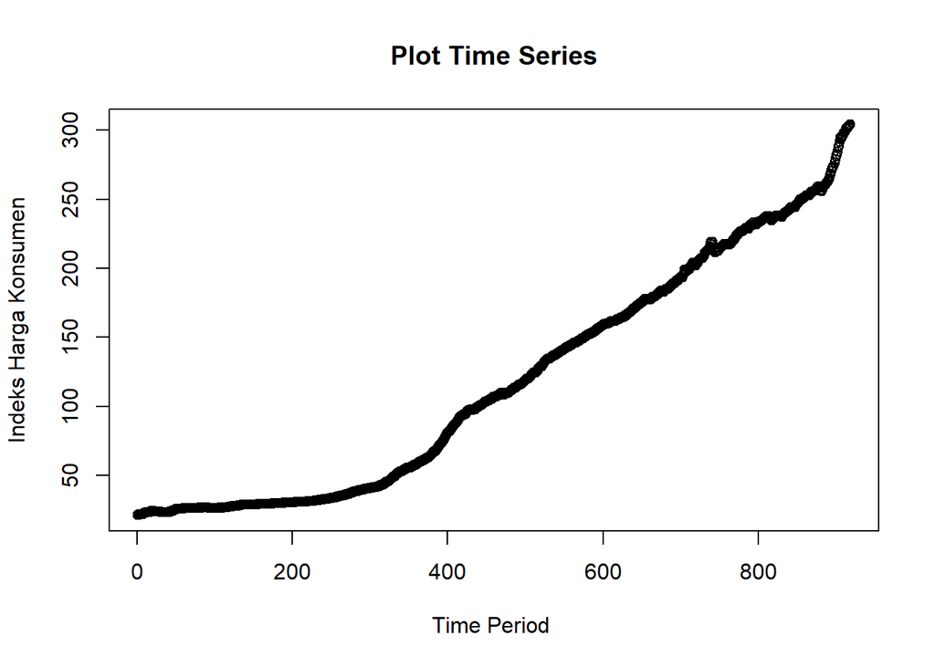

```r
ts.plot(datampdw.ts, xlab="Time Period ", ylab="Indeks Harga Konsumen",
        main = "Plot Time Series")
points(datampdw.ts)
```

#Single Moving Average & Double Moving Average Data pada plot menggambarkan pola data trend naik yang berarti akan cocok menggunakan pemulusan dengan Double Moving Average (DMA). Karena proses DMA melalui proses SMA, maka akan dibandingkan juga hasil SMA dengan DMA.

```r
training <- datampdw[1:735,]
testing <- datampdw[736:918,]
train.ts <- ts(training$`value  (indeks harga konsumen)`)
test.ts <- ts(testing$`value  (indeks harga konsumen)`)
```

#Ekplorasi terhadap ketiga data

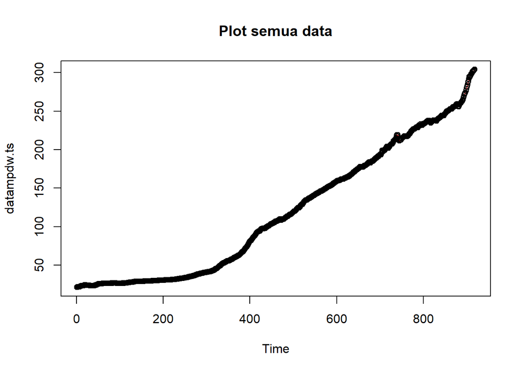

```r
#eksplorasi keseluruhan data
plot(datampdw.ts, col="red",main="Plot semua data")
points(datampdw.ts)
```

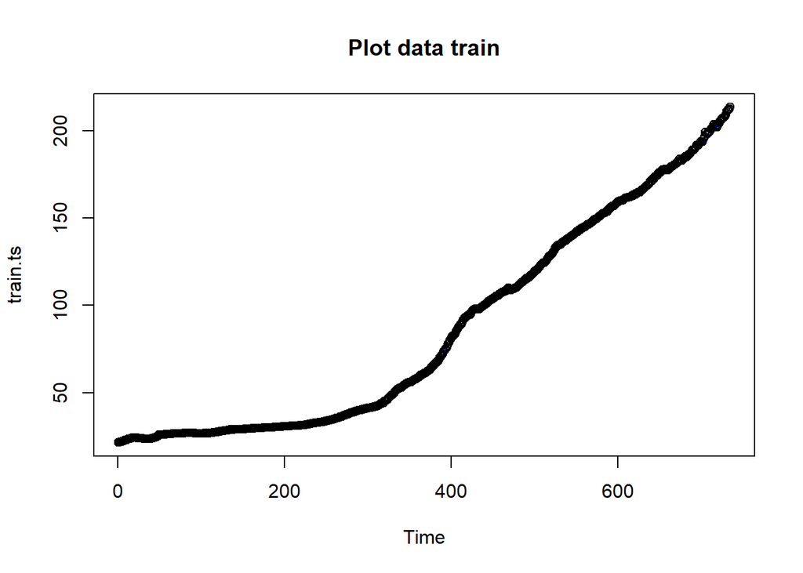

```r
#eksplorasi data latih
plot(train.ts, col="blue",main="Plot data train")
points(train.ts)
```

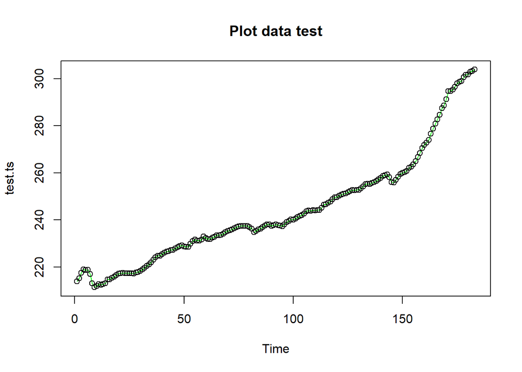

```r
#eksplorasi data uji
plot(test.ts, col="green",main="Plot data test")
points(test.ts)
```

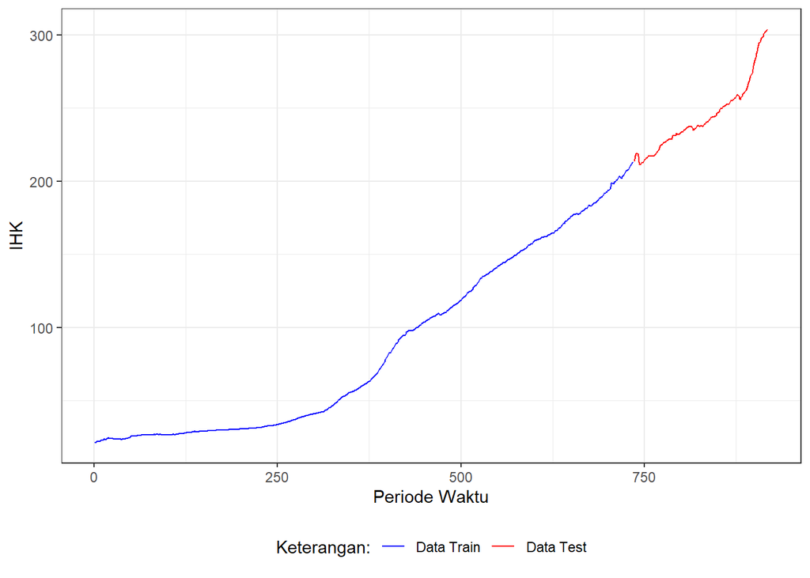

```r
ggplot() +
  geom_line(data = training, aes(x= `Periode ke-`, y = `value  (indeks harga konsumen)` , col = "Data Train")) +
  geom_line(data = testing, aes(x = `Periode ke-`, y = `value  (indeks harga konsumen)` , col = "Data Test")) +
  labs(x = "Periode Waktu", y = "IHK", color = "Legend") +
  scale_colour_manual(name="Keterangan:", breaks = c("Data Train", "Data Test"),
                      values = c("blue", "red")) +
  theme_bw() + theme(legend.position = "bottom",
                     plot.caption = element_text(hjust=0.5, size=12))
```

#Single Moving Average (SMA) Melakukan pemulusan dan peramalan dengan metode SMA

```r
#Pemulusan dengan SMA
data.sma<-SMA(train.ts,n=30)
data.sma
```

```
## Time Series:
## Start = 1
## End = 735
## Frequency = 1
##   [1]        NA        NA        NA        NA        NA        NA        NA
##   [8]        NA        NA        NA        NA        NA        NA        NA
##  [15]        NA        NA        NA        NA        NA        NA        NA
##  [22]        NA        NA        NA        NA        NA        NA        NA
##  [29]        NA  23.33667  23.41067  23.48000  23.53833  23.59400  23.65233
##  [36]  23.70333  23.74600  23.78633  23.81300  23.83767  23.86133  23.87700
##  [43]  23.89000  23.90767  23.93567  23.95833  23.97800  24.00567  24.03833
##  [50]  24.08500  24.13567  24.18933  24.25033  24.31300  24.37633  24.44133
##  [57]  24.51200  24.58667  24.66700  24.75200  24.84367  24.93400  25.02200
##  [64]  25.11500  25.20733  25.30467  25.41033  25.51300  25.61267  25.71400
##  [71]  25.81133  25.90567  25.99133  26.07100  26.14733  26.22033  26.29033
```

[output cut: 94 more lines]

```r
#Peramalan 1 periode ke depan
data.ramal<-c(NA,data.sma)
data.ramal
```

```
##   [1]        NA        NA        NA        NA        NA        NA        NA
##   [8]        NA        NA        NA        NA        NA        NA        NA
##  [15]        NA        NA        NA        NA        NA        NA        NA
##  [22]        NA        NA        NA        NA        NA        NA        NA
##  [29]        NA        NA  23.33667  23.41067  23.48000  23.53833  23.59400
##  [36]  23.65233  23.70333  23.74600  23.78633  23.81300  23.83767  23.86133
##  [43]  23.87700  23.89000  23.90767  23.93567  23.95833  23.97800  24.00567
##  [50]  24.03833  24.08500  24.13567  24.18933  24.25033  24.31300  24.37633
##  [57]  24.44133  24.51200  24.58667  24.66700  24.75200  24.84367  24.93400
##  [64]  25.02200  25.11500  25.20733  25.30467  25.41033  25.51300  25.61267
##  [71]  25.71400  25.81133  25.90567  25.99133  26.07100  26.14733  26.22033
##  [78]  26.29033  26.35000  26.39700  26.43100  26.46467  26.49900  26.52767
##  [85]  26.55900  26.59333  26.63100  26.66100  26.68433  26.70467  26.72033
##  [92]  26.73400  26.74867  26.76267  26.77133  26.78167  26.78967  26.79267
##  [99]  26.79700  26.80233  26.80567  26.80833  26.80833  26.81233  26.81667
```

[output cut: 91 more lines]

```r
#Peramalan 183 periode ke depan
data.gab<-cbind(aktual=c(train.ts,rep(NA,183)),pemulusan=c(data.sma,rep(NA,183)),ramalan=c(data.ramal,rep(data.ramal[length(data.ramal)],182)))
data.gab
```

```
##         aktual pemulusan   ramalan
##   [1,]  21.480        NA        NA
##   [2,]  21.620        NA        NA
##   [3,]  22.000        NA        NA
##   [4,]  22.000        NA        NA
##   [5,]  21.950        NA        NA
##   [6,]  22.080        NA        NA
##   [7,]  22.230        NA        NA
##   [8,]  22.400        NA        NA
##   [9,]  22.840        NA        NA
##  [10,]  22.910        NA        NA
##  [11,]  23.060        NA        NA
##  [12,]  23.410        NA        NA
##  [13,]  23.680        NA        NA
##  [14,]  23.670        NA        NA
```

[output cut: 904 more lines]

#Plot deret waktu peramalan dengan SMA

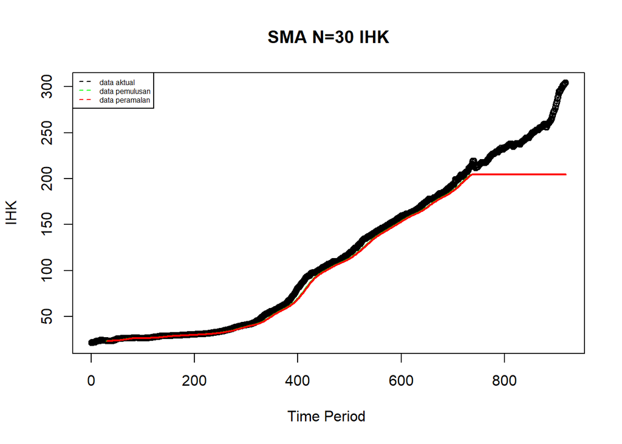

```r
ts.plot(datampdw.ts, xlab="Time Period ", ylab="IHK", main= "SMA N=30 IHK")
points(datampdw.ts)
lines(data.gab[,2],col="green",lwd=2)
lines(data.gab[,3],col="red",lwd=2)
legend("topleft",c("data aktual","data pemulusan","data peramalan"), lty=8, col=c("black","green","red"), cex=0.5)
```

#Menghitung keakuratan data training SMA

```r
#Menghitung nilai keakuratan data latih
error_train.sma = train.ts-data.ramal[1:length(train.ts)]
SSE_train.sma = sum(error_train.sma[31:length(train.ts)]^2)
MSE_train.sma = mean(error_train.sma[31:length(train.ts)]^2)
MAPE_train.sma = mean(abs((error_train.sma[31:length(train.ts)]/train.ts[31:length(train.ts)])*100))

akurasi_train.sma <- matrix(c(SSE_train.sma, MSE_train.sma, MAPE_train.sma))
row.names(akurasi_train.sma)<- c("SSE", "MSE", "MAPE")
colnames(akurasi_train.sma) <- c("Akurasi m = 30")
akurasi_train.sma
```

```
##      Akurasi m = 30
## SSE    17784.102098
## MSE       25.225677
## MAPE       4.558314
```

Berdasarkan hasil perhitungan akurasi data latih menggunakan m=30 dengan metode SMA menghasilkan nilai MAPE yang kurang dari 10% sehingga nilai akurasi ini dapat dikategorikan sebagai sangat baik.

#Menghitung keakuratan data testing SMA

```r
error_test.sma = test.ts-data.gab[736:918,3]
SSE_test.sma = sum(error_test.sma^2)
MSE_test.sma = mean(error_test.sma^2)
MAPE_test.sma = mean(abs((error_test.sma/test.ts*100)))

akurasi_test.sma <- matrix(c(SSE_test.sma, MSE_test.sma, MAPE_test.sma))
row.names(akurasi_test.sma)<- c("SSE", "MSE", "MAPE")
colnames(akurasi_test.sma) <- c("Akurasi m = 30")
akurasi_test.sma
```

```
##      Akurasi m = 30
## SSE    381979.12993
## MSE      2087.31765
## MAPE       15.40867
```

Berdasarkan hasil perhitungan akurasi data uji menggunakan m=30 dengan metode SMA menghasilkan nilai MAPE yang lebih dari 10% sehingga nilai akurasi ini dapat dikategorikan sebagai kurang baik.

#Double Moving Average (DMA)

```r
dma <- SMA(data.sma, n = 30)
At <- 2*data.sma - dma
Bt <- 2/(30-1)*(data.sma - dma)
data.dma<- At+Bt
data.ramal2<- c(NA, data.dma)

t = 1:183
f = c()

for (i in t) {
  f[i] = At[length(At)] + Bt[length(Bt)]*(i)
}

data.gab2 <- cbind(aktual = c(train.ts,rep(NA,183)), pemulusan1 = c(data.sma,rep(NA,183)),pemulusan2 = c(data.dma, rep(NA,183)),At = c(At, rep(NA,183)), Bt = c(Bt,rep(NA,183)),ramalan = c(data.ramal2, f[-1]))
data.gab2
```

```
##         aktual pemulusan1 pemulusan2        At          Bt   ramalan
##   [1,]  21.480         NA         NA        NA          NA        NA
##   [2,]  21.620         NA         NA        NA          NA        NA
##   [3,]  22.000         NA         NA        NA          NA        NA
##   [4,]  22.000         NA         NA        NA          NA        NA
##   [5,]  21.950         NA         NA        NA          NA        NA
##   [6,]  22.080         NA         NA        NA          NA        NA
##   [7,]  22.230         NA         NA        NA          NA        NA
##   [8,]  22.400         NA         NA        NA          NA        NA
##   [9,]  22.840         NA         NA        NA          NA        NA
##  [10,]  22.910         NA         NA        NA          NA        NA
##  [11,]  23.060         NA         NA        NA          NA        NA
##  [12,]  23.410         NA         NA        NA          NA        NA
##  [13,]  23.680         NA         NA        NA          NA        NA
##  [14,]  23.670         NA         NA        NA          NA        NA
```

[output cut: 904 more lines]

#Visualisasi hasil pemulusan

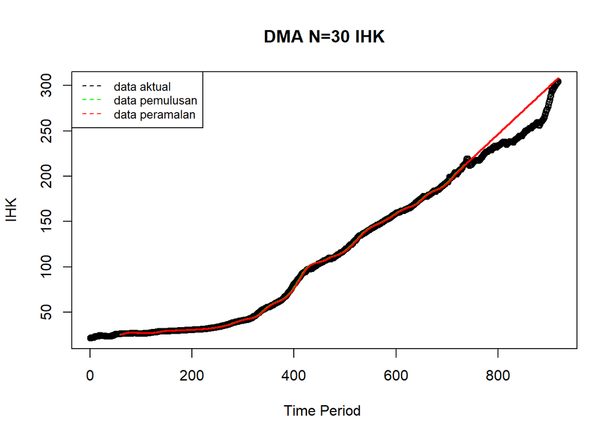

```r
ts.plot(datampdw.ts, xlab="Time Period ", ylab="IHK", main= "DMA N=30 IHK")
points(datampdw.ts)
lines(data.gab2[,3],col="green",lwd=2)
lines(data.gab2[,6],col="red",lwd=2)
legend("topleft",c("data aktual","data pemulusan","data peramalan"), lty=8, col=c("black","green","red"), cex=0.8)
```

#Perhitungan akurasi data training DMA

```r
error_train.dma = train.ts-data.ramal2[1:length(train.ts)]
SSE_train.dma = sum(error_train.dma[60:length(train.ts)]^2)
MSE_train.dma = mean(error_train.dma[60:length(train.ts)]^2)
MAPE_train.dma = mean(abs((error_train.dma[60:length(train.ts)]/train.ts[60:length(train.ts)])*100))

akurasi_train.dma <- matrix(c(SSE_train.dma, MSE_train.dma, MAPE_train.dma))
row.names(akurasi_train.dma)<- c("SSE", "MSE", "MAPE")
colnames(akurasi_train.dma) <- c("Akurasi m = 30")
akurasi_train.dma
```

```
##      Akurasi m = 30
## SSE     1224.348721
## MSE        1.811167
## MAPE       1.258431
```

Berdasarkan hasil perhitungan akurasi data training menggunakan m=30 dengan metode DMA menghasilkan nilai MAPE yang kurang dari 10% sehingga nilai akurasi ini dapat dikategorikan sebagai sangat baik.

#Perhitungan akurasi data testing DMA

```r
error_test.dma = test.ts-data.gab2[736:918,6]
SSE_test.dma = sum(error_test.dma^2)
MSE_test.dma = mean(error_test.dma^2)
MAPE_test.dma = mean(abs((error_test.dma/test.ts*100)))

akurasi_test.dma <- matrix(c(SSE_test.dma, MSE_test.dma, MAPE_test.dma))
row.names(akurasi_test.dma)<- c("SSE", "MSE", "MAPE")
colnames(akurasi_test.dma) <- c("Akurasi m = 30")
akurasi_test.dma
```

```
##      Akurasi m = 30
## SSE    66259.672205
## MSE      362.074712
## MAPE       6.778596
```

Berdasarkan hasil perhitungan akurasi data testing menggunakan m=30 dengan metode DMA menghasilkan nilai MAPE yang kurang dari 10% sehingga nilai akurasi ini dapat dikategorikan sebagai sangat baik.

#Perbandingan SMA dengan DMA

```r
MSEpenuh <- cbind(akurasi_test.sma,akurasi_test.dma)
colnames(MSEpenuh)<-c("sma","dma")
MSEpenuh
```

```
##               sma          dma
## SSE  381979.12993 66259.672205
## MSE    2087.31765   362.074712
## MAPE     15.40867     6.778596
```

#Metode pemulusan dengan eksponensial ganda (DES) Selain pemulusan dengan DMA (Double Moving Average), data yang memiliki pola trend dapat juga melalui pemulusan dengan pemulusan eksponensial ganda. Pemulusan DES menggunakan Holtwinters. Gamma adalah parameter pemulusan untuk komponen musiman, Beta adalah parameter pemulusan untuk tren, dan Alpha adalah parameter pemulusan untuk stasioner, serta h adalah banyaknya periode yang akan diramalkan. Pada DES, nilai Alpha diinisiasi bersama dengan Beta.

#Percobaan nilai Alpha dan Beta

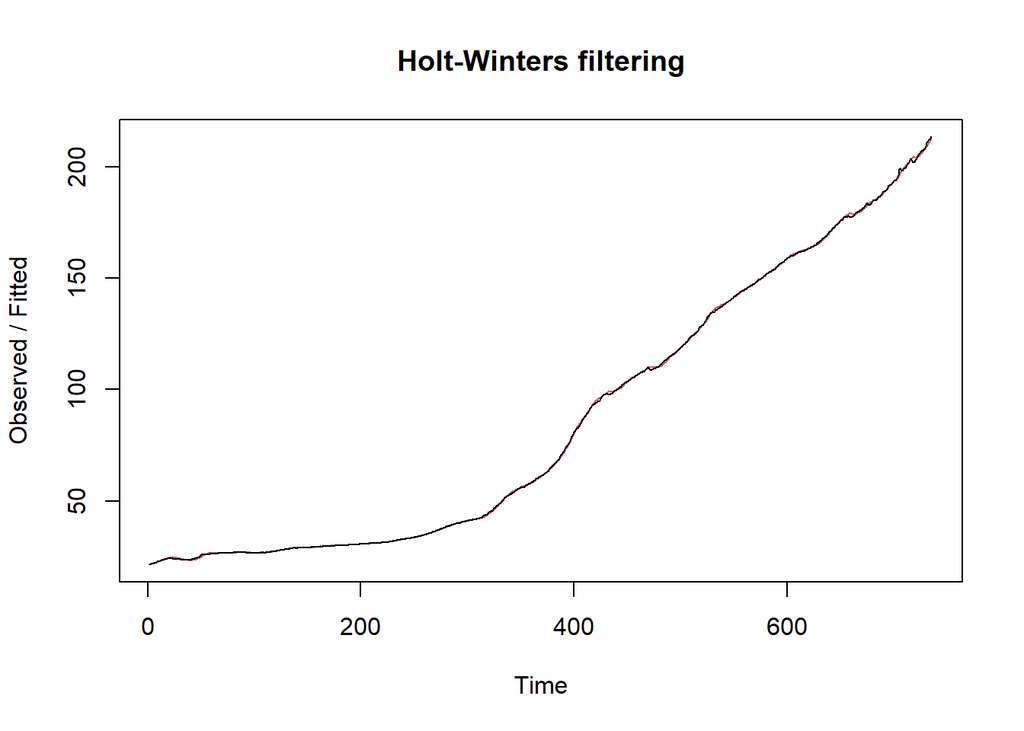

```r
#Alpha =0.2 dan beta = 0.2
des.1<- HoltWinters(train.ts, gamma = FALSE, beta = 0.2, alpha = 0.2)
plot(des.1)
```

```r
#ramalan 183 periode ke depan
ramalandes1<- forecast(des.1,183)
ramalandes1
```

```
##     Point Forecast    Lo 80    Hi 80    Lo 95    Hi 95
## 736       213.6568 213.0710 214.2427 212.7609 214.5528
## 737       214.3922 213.7897 214.9947 213.4708 215.3136
## 738       215.1276 214.5032 215.7520 214.1727 216.0825
## 739       215.8630 215.2110 216.5149 214.8659 216.8600
## 740       216.5984 215.9132 217.2836 215.5504 217.6463
## 741       217.3338 216.6096 218.0579 216.2262 218.4413
## 742       218.0691 217.3005 218.8378 216.8936 219.2447
## 743       218.8045 217.9860 219.6230 217.5527 220.0563
## 744       219.5399 218.6666 220.4133 218.2042 220.8756
## 745       220.2753 219.3424 221.2082 218.8485 221.7021
## 746       221.0107 220.0137 222.0076 219.4860 222.5354
## 747       221.7461 220.6809 222.8112 220.1171 223.3750
## 748       222.4815 221.3443 223.6186 220.7423 224.2206
## 749       223.2168 222.0039 224.4297 221.3619 225.0718
```

[output cut: 169 more lines]

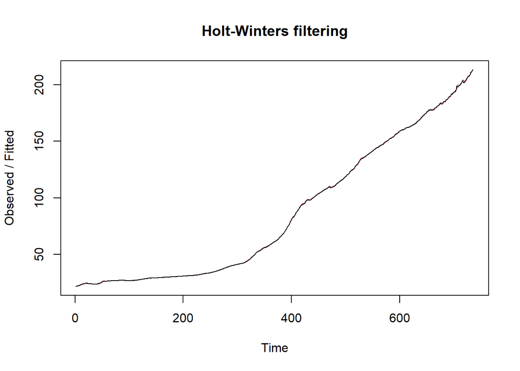

```r
#Alpha =0.6 dan beta = 0.3
des.2<- HoltWinters(train.ts, gamma = FALSE, beta = 0.3, alpha = 0.6)
plot(des.2)
```

```r
#ramalan 183 periode ke depan
ramalandes2<- forecast(des.2,183)
ramalandes2
```

```
##     Point Forecast    Lo 80    Hi 80    Lo 95    Hi 95
## 736       214.2452 213.8605 214.6299 213.6568 214.8335
## 737       214.9921 214.5042 215.4800 214.2459 215.7383
## 738       215.7390 215.1270 216.3509 214.8031 216.6748
## 739       216.4859 215.7330 217.2387 215.3344 217.6373
## 740       217.2327 216.3246 218.1409 215.8439 218.6216
## 741       217.9796 216.9037 219.0556 216.3341 219.6252
## 742       218.7265 217.4714 219.9817 216.8069 220.6461
## 743       219.4734 218.0286 220.9182 217.2638 221.6831
## 744       220.2203 218.5761 221.8645 217.7057 222.7349
## 745       220.9672 219.1144 222.8200 218.1336 223.8008
## 746       221.7141 219.6440 223.7842 218.5481 224.8801
## 747       222.4610 220.1652 224.7568 218.9499 225.9721
## 748       223.2079 220.6784 225.7373 219.3394 227.0763
## 749       223.9548 221.1840 226.7256 219.7172 228.1924
```

[output cut: 169 more lines]

#Mencari nilai Alpha dan Beta optimum

```r
des.opt<- HoltWinters(train.ts, gamma = FALSE)
des.opt
```

```
## Holt-Winters exponential smoothing with trend and without seasonal component.
##
## Call:
## HoltWinters(x = train.ts, gamma = FALSE)
##
## Smoothing parameters:
##  alpha: 1
##  beta : 0.1166179
##  gamma: FALSE
##
## Coefficients:
##          [,1]
## a 213.4480000
## b   0.6581467
```

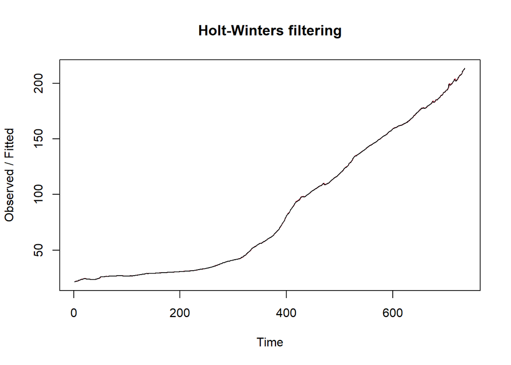

```r
plot(des.opt)
```

```r
#ramalan 183 periode ke depan
ramalandesopt<- forecast(des.opt, h=183)
ramalandesopt
```

```
##     Point Forecast    Lo 80    Hi 80    Lo 95    Hi 95
## 736       214.1061 213.7831 214.4292 213.6121 214.6002
## 737       214.7643 214.2801 215.2485 214.0238 215.5048
## 738       215.4224 214.7954 216.0495 214.4635 216.3814
## 739       216.0806 215.3169 216.8443 214.9126 217.2486
## 740       216.7387 215.8400 217.6374 215.3643 218.1132
## 741       217.3969 216.3629 218.4309 215.8155 218.9783
## 742       218.0550 216.8843 219.2258 216.2645 219.8455
## 743       218.7132 217.4036 220.0227 216.7104 220.7159
## 744       219.3713 217.9205 220.8221 217.1526 221.5901
## 745       220.0295 218.4348 221.6242 217.5906 222.4683
## 746       220.6876 218.9462 222.4291 218.0243 223.3509
## 747       221.3458 219.4546 223.2369 218.4535 224.2380
## 748       222.0039 219.9601 224.0477 218.8782 225.1297
## 749       222.6621 220.4626 224.8615 219.2982 226.0259
```

[output cut: 169 more lines]

#Membuat plot pemulusan

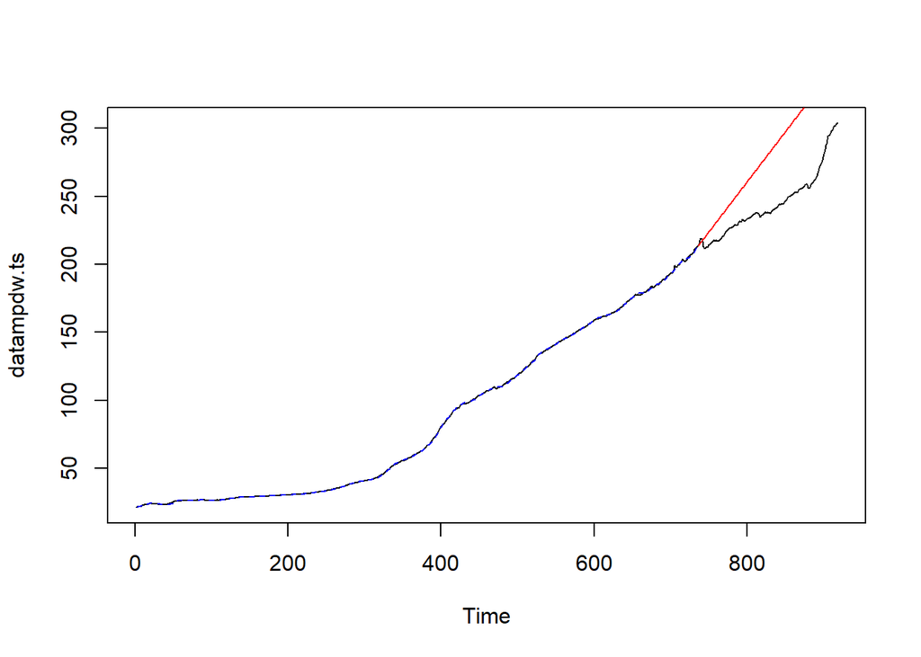

```r
plot(datampdw.ts)
lines(des.1$fitted[,1], lty=2, col="blue")
lines(ramalandes1$mean, col="red")
```

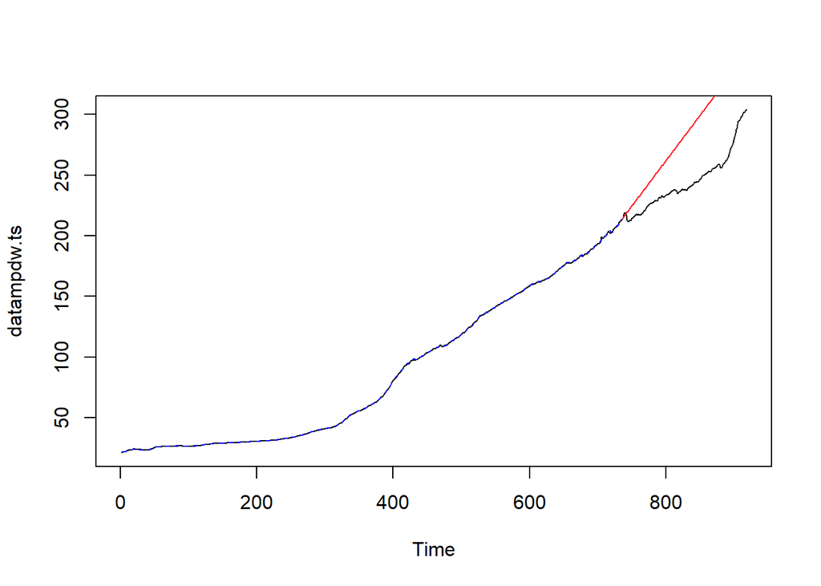

```r
plot(datampdw.ts)
lines(des.2$fitted[,1], lty=2, col="blue")
lines(ramalandes2$mean, col="red")
```

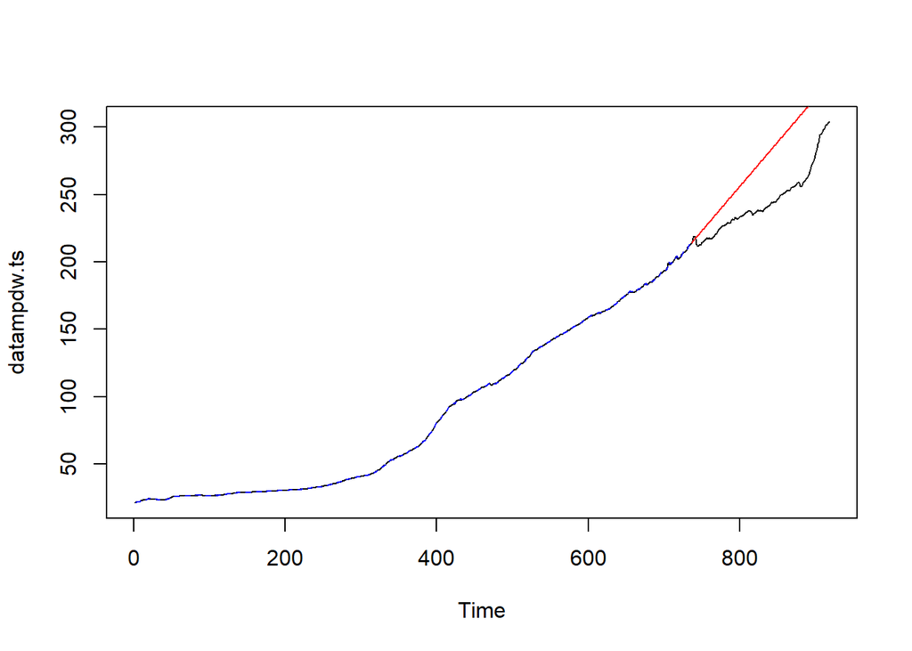

```r
plot(datampdw.ts)
lines(des.opt$fitted[,1], lty=2, col="blue")
lines(ramalandesopt$mean, col="red")
```

#Menghitung akurasi data training pada DES

```r
#Akurasi Data Training
ssedes.train1<-des.1$SSE
msedes.train1<-ssedes.train1/length(train.ts)
sisaandes1<-ramalandes1$residuals
head(sisaandes1)
```

```
## Time Series:
## Start = 1
## End = 6
## Frequency = 1
## [1]         NA         NA  0.2400000  0.0424000 -0.1673760 -0.1485018
```

```r
mapedes.train1 <- sum(abs(sisaandes1[3:length(train.ts)]/train.ts[3:length(train.ts)])
                      *100)/length(train.ts)

akurasides.1 <- matrix(c(ssedes.train1,msedes.train1,mapedes.train1))
row.names(akurasides.1)<- c("SSE", "MSE", "MAPE")
colnames(akurasides.1) <- c("Akurasi lamda=0.2 dan gamma=0.2")
akurasides.1
```

```
##      Akurasi lamda=0.2 dan gamma=0.2
## SSE                      153.2666428
## MSE                        0.2085260
## MAPE                       0.4287199
```

```r
ssedes.train2<-des.2$SSE
msedes.train2<-ssedes.train2/length(train.ts)
sisaandes2<-ramalandes2$residuals
head(sisaandes2)
```

```
## Time Series:
## Start = 1
## End = 6
## Frequency = 1
## [1]          NA          NA  0.24000000 -0.08720000 -0.25238400 -0.09302848
```

```r
mapedes.train2 <- sum(abs(sisaandes2[3:length(train.ts)]/train.ts[3:length(train.ts)])
                      *100)/length(train.ts)

akurasides.2 <- matrix(c(ssedes.train2,msedes.train2,mapedes.train2))
row.names(akurasides.2)<- c("SSE", "MSE", "MAPE")
colnames(akurasides.2) <- c("Akurasi lamda=0.6 dan gamma=0.3")
akurasides.2
```

```
##      Akurasi lamda=0.6 dan gamma=0.3
## SSE                      65.98177886
## MSE                       0.08977113
## MAPE                      0.21876679
```

```r
ssedes.trainopt<-des.opt$SSE
msedes.trainopt<-ssedes.trainopt/length(train.ts)
sisaandesopt<-ramalandesopt$residuals
head(sisaandesopt)
```

```
## Time Series:
## Start = 1
## End = 6
## Frequency = 1
## [1]           NA           NA  0.240000000 -0.167988304 -0.198397855
## [6]  0.004738892
```

```r
mapedes.trainopt <- sum(abs(sisaandesopt[3:length(train.ts)]/train.ts[3:length(train.ts)])
                      *100)/length(train.ts)

akurasides.opt <- matrix(c(ssedes.trainopt,msedes.trainopt,mapedes.trainopt))
row.names(akurasides.opt)<- c("SSE", "MSE", "MAPE")
colnames(akurasides.opt) <- c("Akurasi Alpha dan Beta optimum")
akurasides.opt
```

```
##      Akurasi Alpha dan Beta optimum
## SSE                     46.53333941
## MSE                      0.06331067
## MAPE                     0.18738801
```

Pada pemulusan dengan DES di data train atau data latih, ketiga nilai Alpha dan Beta yang dicobakan memberikan hasil nilai MAPE yang kurang dari 10%, sehingga dapat dikategorikan sangat baik. Dari ketiga percobaan nilai alpha dan beta, nilai alpha dan beta yang dicari pada kondisi optimum memberikan nilai MAPE dan MSE yang paling kecil.

#Menghitung akurasi data test pada DES

```r
selisihdes1<-ramalandes1$mean-testing$`value  (indeks harga konsumen)`
selisihdes1
```

```
## Time Series:
## Start = 736
## End = 918
## Frequency = 1
##   [1] -0.2851794 -0.8157932 -2.3354069 -3.1530207 -2.0916345 -1.5432483
##   [7]  1.0741380  5.6515242  8.1419104  8.3422966  8.3056829  9.2510691
##  [13]  9.7724553 10.1948415  9.1622278  9.9616140  9.9780002 10.2973865
##  [19] 10.3847727 10.3951589 11.0175451 11.6119314 12.5543176 13.2177038
##  [25] 13.9030900 14.7514763 15.5778625 15.9072487 16.3246349 16.7080212
##  [31] 16.6834074 16.8637936 16.7171799 16.7375661 16.7619523 16.3493385
##  [37] 16.0377248 16.0601110 16.7954972 16.9418834 16.9662697 17.2106559
##  [43] 17.7930421 18.1094283 18.7908146 18.9072008 19.1555870 19.4129733
##  [49] 19.7683595 20.9777457 21.9021319 22.5715182 21.9789044 21.6172906
##  [55] 21.7296768 22.8540631 23.6174493 23.8948355 23.3722218 24.7626080
##  [61] 25.9829942 26.6223804 26.8057667 27.0861529 27.2655391 27.9129253
```

[output cut: 20 more lines]

```r
SSEtestingdes1<-sum(selisihdes1^2)
MSEtestingdes1<-SSEtestingdes1/length(testing$`value  (indeks harga konsumen)`)
MAPEtestingdes1<-sum(abs(selisihdes1/testing$`value  (indeks harga konsumen)`)*100)/length(testing$`value  (indeks harga konsumen)`)

selisihdes2<-ramalandes2$mean-testing$`value  (indeks harga konsumen)`
selisihdes2
```

```
## Time Series:
## Start = 736
## End = 918
## Frequency = 1
##   [1]  0.3031753 -0.2159319 -1.7240392 -2.5301465 -1.4572537 -0.8973610
##   [7]  1.7315317  6.3204245  8.8223172  9.0342099  9.0091027  9.9659954
##  [13] 10.4988881 10.9327809  9.9116736 10.7225663 10.7504591 11.0813518
##  [19] 11.1802446 11.2021373 11.8360300 12.4419228 13.3958155 14.0707082
##  [25] 14.7676010 15.6274937 16.4653864 16.8062792 17.2351719 17.6300646
##  [31] 17.6169574 17.8088501 17.6737428 17.7056356 17.7415283 17.3404210
##  [37] 17.0403138 17.0742065 17.8210993 17.9789920 18.0148847 18.2707775
##  [43] 18.8646702 19.1925629 19.8854557 20.0133484 20.2732411 20.5421339
##  [49] 20.9090266 22.1299193 23.0658121 23.7467048 23.1655975 22.8154903
##  [55] 22.9393830 24.0752757 24.8501685 25.1390612 24.6279539 26.0298467
##  [61] 27.2617394 27.9126322 28.1075249 28.3994176 28.5903104 29.2492031
```

[output cut: 20 more lines]

```r
SSEtestingdes2<-sum(selisihdes2^2)
MSEtestingdes2<-SSEtestingdes2/length(testing$`value  (indeks harga konsumen)`)
MAPEtestingdes2<-sum(abs(selisihdes2/testing$`value  (indeks harga konsumen)`)*100)/length(testing$`value  (indeks harga konsumen)`)

selisihdesopt<-ramalandesopt$mean-testing$`value  (indeks harga konsumen)`
selisihdesopt
```

```
## Time Series:
## Start = 736
## End = 918
## Frequency = 1
##   [1]  0.1641467 -0.4437065 -2.0405598 -2.9354131 -1.9512663 -1.4801196
##   [7]  1.0600271  5.5601739  7.9733206  8.0964673  7.9826141  8.8507608
##  [13]  9.2949075  9.6400543  8.5302010  9.2523477  9.1914945  9.4336412
##  [19]  9.4437879  9.3769347  9.9220814 10.4392281 11.3043749 11.8905216
##  [25] 12.4986683 13.2698151 14.0189618 14.2711085 14.6112553 14.9174020
##  [31] 14.8155487 14.9186955 14.6948422 14.6379889 14.5851357 14.0952824
##  [37] 13.7064291 13.6515759 14.3097226 14.3788693 14.3260161 14.4931628
##  [43] 14.9983095 15.2374562 15.8416030 15.8807497 16.0518964 16.2320432
##  [49] 16.5101899 17.6423366 18.4894834 19.0816301 18.4117768 17.9729236
##  [55] 18.0080703 19.0552170 19.7413638 19.9415105 19.3416572 20.6548040
##  [61] 21.7979507 22.3600974 22.4662442 22.6693909 22.7715376 23.3416844
```

[output cut: 20 more lines]

```r
SSEtestingdesopt<-sum(selisihdesopt^2)
MSEtestingdesopt<-SSEtestingdesopt/length(testing$`value  (indeks harga konsumen)`)
MAPEtestingdesopt<-sum(abs(selisihdesopt/testing$`value  (indeks harga konsumen)`)*100)/length(testing$`value  (indeks harga konsumen)`)

akurasitestingdes <-
  matrix(c(SSEtestingdes1,MSEtestingdes1,MAPEtestingdes1,SSEtestingdes2,MSEtestingdes2,
           MAPEtestingdes2,SSEtestingdesopt,MSEtestingdesopt,MAPEtestingdesopt),
         nrow=3,ncol=3)
row.names(akurasitestingdes)<- c("SSE", "MSE", "MAPE")
colnames(akurasitestingdes) <- c("des ske1","des ske2","des opt")
akurasitestingdes
```

```
##          des ske1     des ske2      des opt
## SSE  307030.90254 333222.55102 204771.70029
## MSE    1677.76449   1820.88826   1118.97104
## MAPE     14.61812     15.25518     12.03809
```

Pada pemulusan dengan DES di data test atau data uji, ketiga nilai Alpha dan Beta yang dicobakan memberikan hasil nilai MAPE yang lebih dari 10%. Dari ketiga percobaan nilai alpha dan beta, nilai alpha dan beta yang dicari pada kondisi optimum memberikan nilai MAPE dan MSE yang paling kecil.

#Melakukan metode SES untuk dibandingkan dengan DES Selanjutnya akan dilakukan metode pemulusan SES untuk membandingkan dengan metode pemulusan DES

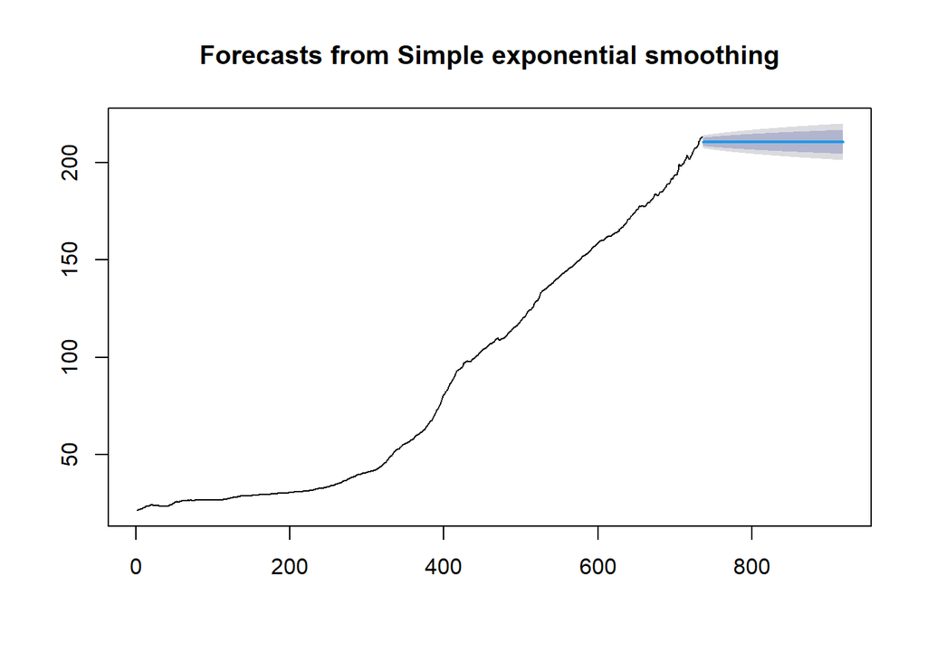

```r
#Pemulusan SES dengan fungsi ses
#Nilai Alpha atau lamda disamakan dengan DES
ses.1 <- ses(train.ts, h = 183, alpha = 0.2)
plot(ses.1)
```

```r
ses.1
```

```
##     Point Forecast    Lo 80    Hi 80    Lo 95    Hi 95
## 736         210.62 208.4969 212.7432 207.3729 213.8671
## 737         210.62 208.4548 212.7852 207.3086 213.9314
## 738         210.62 208.4136 212.8264 207.2456 213.9945
## 739         210.62 208.3731 212.8669 207.1836 214.0564
## 740         210.62 208.3333 212.9067 207.1228 214.1172
## 741         210.62 208.2942 212.9458 207.0630 214.1770
## 742         210.62 208.2558 212.9842 207.0042 214.2358
## 743         210.62 208.2179 213.0221 206.9464 214.2936
## 744         210.62 208.1807 213.0593 206.8894 214.3506
## 745         210.62 208.1440 213.0960 206.8333 214.4067
## 746         210.62 208.1079 213.1321 206.7780 214.4620
## 747         210.62 208.0722 213.1678 206.7235 214.5165
## 748         210.62 208.0371 213.2029 206.6698 214.5702
## 749         210.62 208.0024 213.2376 206.6168 214.6233
```

[output cut: 169 more lines]

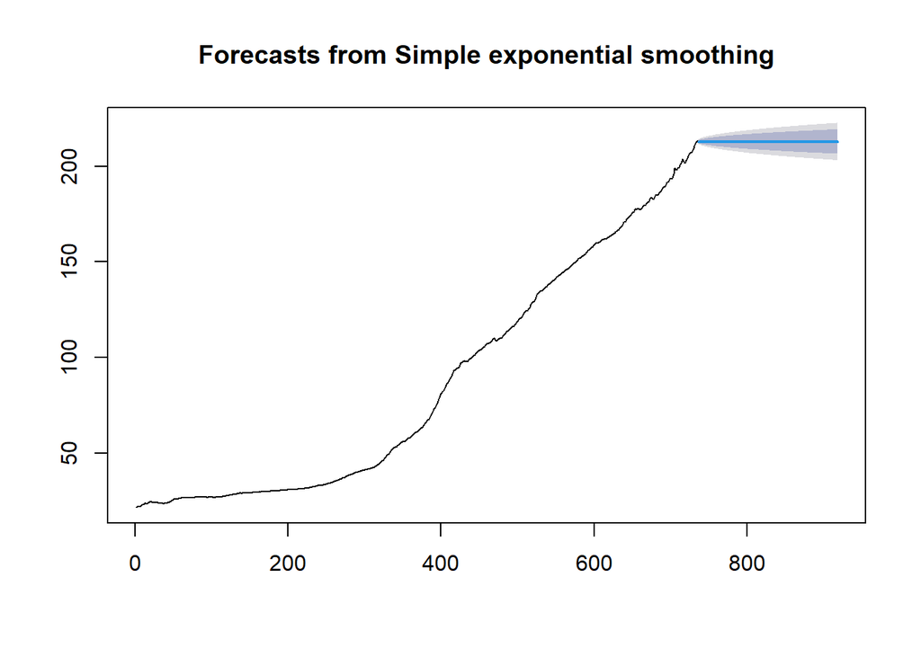

```r
ses.2<- ses(train.ts, h = 183, alpha = 0.6)
plot(ses.2)
```

```r
ses.2
```

```
##     Point Forecast    Lo 80    Hi 80    Lo 95    Hi 95
## 736       212.9781 212.1959 213.7602 211.7818 214.1743
## 737       212.9781 212.0659 213.8902 211.5830 214.3731
## 738       212.9781 211.9522 214.0039 211.4092 214.5469
## 739       212.9781 211.8500 214.1061 211.2528 214.7033
## 740       212.9781 211.7563 214.1999 211.1095 214.8467
## 741       212.9781 211.6692 214.2869 210.9764 214.9798
## 742       212.9781 211.5876 214.3685 210.8516 215.1046
## 743       212.9781 211.5106 214.4456 210.7337 215.2224
## 744       212.9781 211.4374 214.5188 210.6217 215.3344
## 745       212.9781 211.3675 214.5887 210.5149 215.4413
## 746       212.9781 211.3005 214.6557 210.4124 215.5437
## 747       212.9781 211.2361 214.7201 210.3139 215.6422
## 748       212.9781 211.1740 214.7822 210.2189 215.7372
## 749       212.9781 211.1139 214.8422 210.1271 215.8290
```

[output cut: 169 more lines]

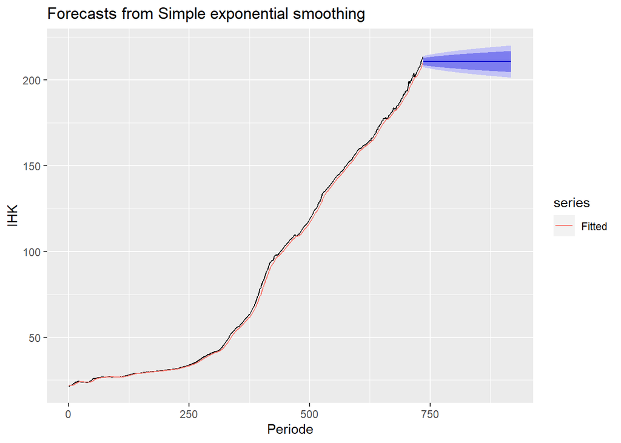

```r
autoplot(ses.1) +
  autolayer(fitted(ses.1), series="Fitted") +
  ylab("IHK") + xlab("Periode")
```

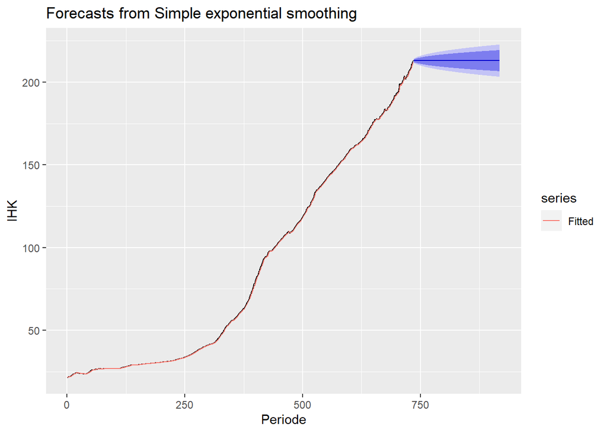

```r
autoplot(ses.2) +
  autolayer(fitted(ses.2), series="Fitted") +
  ylab("IHK") + xlab("Periode")
```

#Pemulusan SES dengan HoltWinter

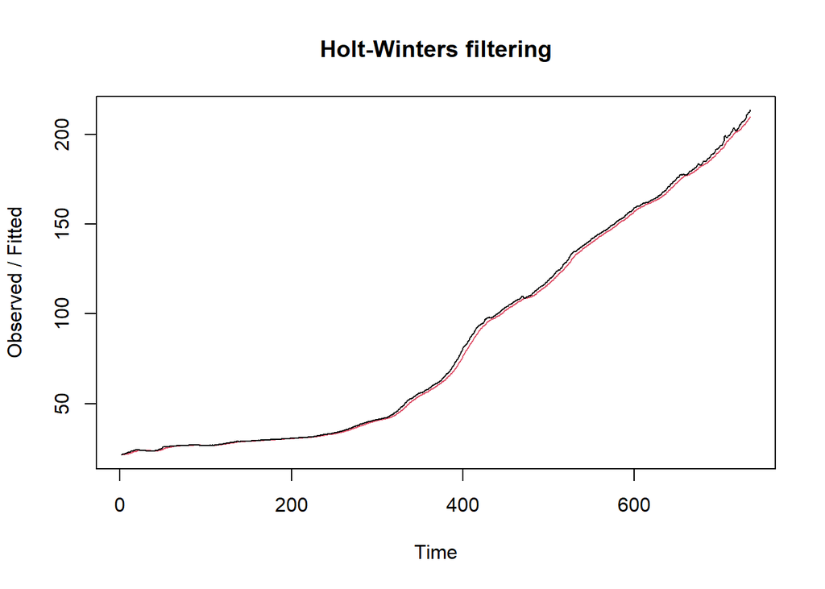

```r
ses1<- HoltWinters(train.ts, gamma = FALSE, beta = FALSE, alpha = 0.2)
plot(ses1)
```

```r
#ramalan 183 periode ke depan
ramalan1<- forecast(ses1, h=183)
ramalan1
```

```
##     Point Forecast    Lo 80    Hi 80    Lo 95    Hi 95
## 736         210.62 209.2859 211.9542 208.5796 212.6604
## 737         210.62 209.2594 211.9806 208.5392 212.7008
## 738         210.62 209.2335 212.0065 208.4995 212.7405
## 739         210.62 209.2081 212.0320 208.4606 212.7794
## 740         210.62 209.1831 212.0569 208.4224 212.8176
## 741         210.62 209.1585 212.0815 208.3848 212.8552
## 742         210.62 209.1344 212.1057 208.3479 212.8921
## 743         210.62 209.1106 212.1294 208.3115 212.9285
## 744         210.62 209.0872 212.1528 208.2757 212.9643
## 745         210.62 209.0641 212.1759 208.2405 212.9995
## 746         210.62 209.0414 212.1986 208.2058 213.0343
## 747         210.62 209.0190 212.2210 208.1715 213.0685
## 748         210.62 208.9969 212.2431 208.1377 213.1023
## 749         210.62 208.9752 212.2649 208.1044 213.1356
```

[output cut: 169 more lines]

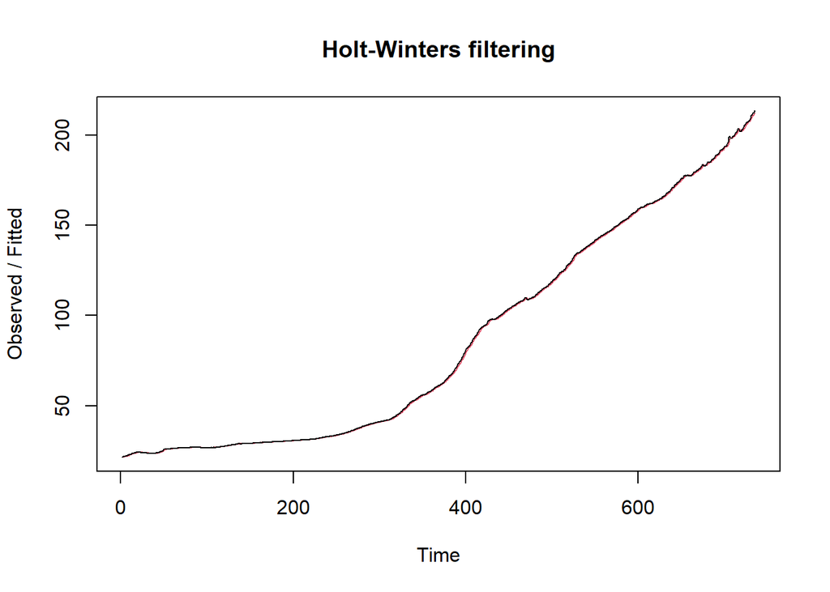

```r
ses2<- HoltWinters(train.ts, gamma = FALSE, beta = FALSE, alpha = 0.6)
plot(ses2)
```

```r
#ramalan 183 periode ke depan
ramalan2<- forecast(ses2, h=183)
ramalan2
```

```
##     Point Forecast    Lo 80    Hi 80    Lo 95    Hi 95
## 736       212.9781 212.4295 213.5266 212.1392 213.8170
## 737       212.9781 212.3384 213.6178 211.9997 213.9564
## 738       212.9781 212.2587 213.6975 211.8779 214.0783
## 739       212.9781 212.1870 213.7692 211.7682 214.1880
## 740       212.9781 212.1212 213.8349 211.6677 214.2885
## 741       212.9781 212.0602 213.8959 211.5743 214.3818
## 742       212.9781 212.0030 213.9532 211.4868 214.4693
## 743       212.9781 211.9489 214.0072 211.4041 214.5520
## 744       212.9781 211.8976 214.0585 211.3256 214.6305
## 745       212.9781 211.8486 214.1076 211.2507 214.7055
## 746       212.9781 211.8016 214.1545 211.1788 214.7773
## 747       212.9781 211.7564 214.1997 211.1097 214.8464
## 748       212.9781 211.7129 214.2433 211.0431 214.9130
## 749       212.9781 211.6708 214.2854 210.9787 214.9774
```

[output cut: 169 more lines]

#Mencari nilai Alpha optimum

```r
ses.opt <- ses(train.ts, h = 183, alpha = NULL)
ses.opt
```

```
##     Point Forecast    Lo 80    Hi 80    Lo 95    Hi 95
## 736       213.4479 212.9285 213.9673 212.6536 214.2423
## 737       213.4479 212.7134 214.1824 212.3246 214.5713
## 738       213.4479 212.5483 214.3475 212.0721 214.8237
## 739       213.4479 212.4092 214.4867 211.8593 215.0365
## 740       213.4479 212.2866 214.6093 211.6718 215.2240
## 741       213.4479 212.1758 214.7201 211.5023 215.3935
## 742       213.4479 212.0738 214.8220 211.3464 215.5494
## 743       213.4479 211.9790 214.9169 211.2013 215.6945
## 744       213.4479 211.8899 215.0060 211.0651 215.8308
## 745       213.4479 211.8056 215.0903 210.9362 215.9597
## 746       213.4479 211.7254 215.1704 210.8136 216.0823
## 747       213.4479 211.6488 215.2470 210.6964 216.1994
## 748       213.4479 211.5754 215.3205 210.5841 216.3118
## 749       213.4479 211.5047 215.3912 210.4760 216.4199
```

[output cut: 169 more lines]

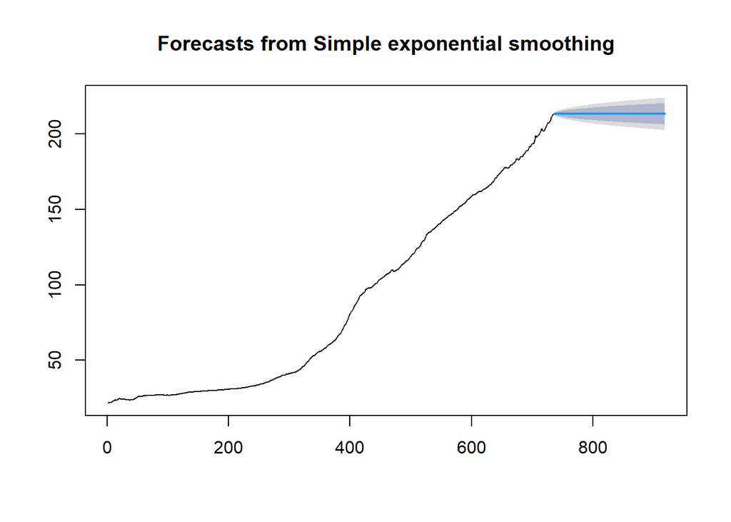

```r
plot(ses.opt)
```

```r
#Alpha optimum dengan Holt Winter
sesopt<- HoltWinters(train.ts, gamma = FALSE, beta = FALSE,alpha = NULL)
sesopt
```

```
## Holt-Winters exponential smoothing without trend and without seasonal component.
##
## Call:
## HoltWinters(x = train.ts, alpha = NULL, beta = FALSE, gamma = FALSE)
##
## Smoothing parameters:
##  alpha: 0.9999493
##  beta : FALSE
##  gamma: FALSE
##
## Coefficients:
##      [,1]
## a 213.448
```

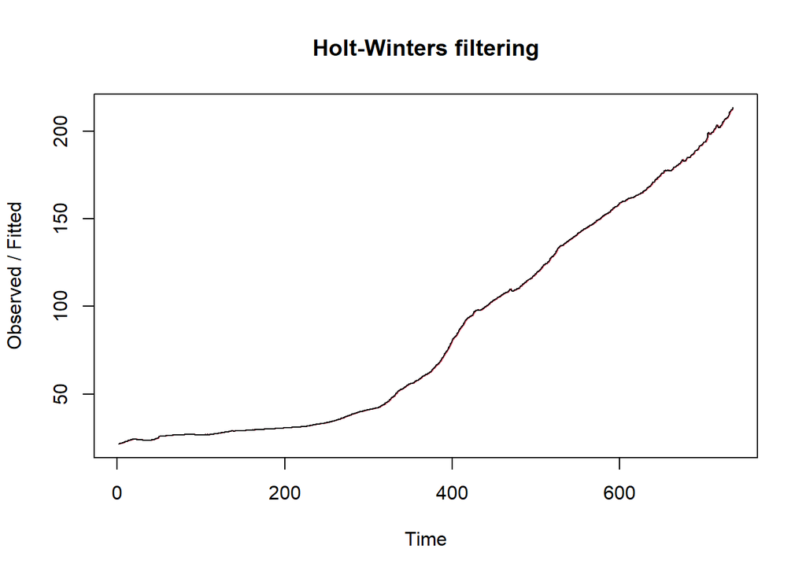

```r
plot(sesopt)
```

```r
#ramalan 183 periode ke depan
ramalanopt<- forecast(sesopt, h=183)
ramalanopt
```

```
##     Point Forecast    Lo 80    Hi 80    Lo 95    Hi 95
## 736        213.448 213.0514 213.8445 212.8415 214.0544
## 737        213.448 212.8872 214.0088 212.5903 214.3056
## 738        213.448 212.7611 214.1348 212.3975 214.4984
## 739        213.448 212.6549 214.2410 212.2351 214.6609
## 740        213.448 212.5613 214.3346 212.0919 214.8040
## 741        213.448 212.4766 214.4193 211.9625 214.9335
## 742        213.448 212.3988 214.4971 211.8434 215.0525
## 743        213.448 212.3264 214.5695 211.7327 215.1633
## 744        213.448 212.2584 214.6376 211.6286 215.2673
## 745        213.448 212.1940 214.7019 211.5302 215.3657
## 746        213.448 212.1328 214.7631 211.4366 215.4593
## 747        213.448 212.0743 214.8216 211.3472 215.5488
## 748        213.448 212.0182 214.8777 211.2614 215.6345
## 749        213.448 211.9643 214.9317 211.1788 215.7171
```

[output cut: 169 more lines]

#Menghitung akurasi pada data train atau data latih pada SES

```r
fitted1<-ramalan1$fitted
sisaan1<-ramalan1$residuals
head(sisaan1)
```

```
## Time Series:
## Start = 1
## End = 6
## Frequency = 1
## [1]       NA 0.140000 0.492000 0.393600 0.264880 0.341904
```

```r
resid1<-training$`value  (indeks harga konsumen)`-ramalan1$fitted
head(resid1)
```

```
## Time Series:
## Start = 1
## End = 6
## Frequency = 1
## [1]       NA 0.140000 0.492000 0.393600 0.264880 0.341904
```

```r
SSE.1=sum(sisaan1[2:length(train.ts)]^2)
SSE.1
```

```
## [1] 2012.871
```

```r
MSE.1 = SSE.1/length(train.ts)
MSE.1
```

```
## [1] 2.7386
```

```r
MAPE.1 = sum(abs(sisaan1[2:length(train.ts)]/train.ts[2:length(train.ts)])*
               100)/length(train.ts)
MAPE.1
```

```
## [1] 1.549317
```

```r
akurasi.1 <- matrix(c(SSE.1,MSE.1,MAPE.1))
row.names(akurasi.1)<- c("SSE", "MSE", "MAPE")
colnames(akurasi.1) <- c("Akurasi lamda=0.2")
akurasi.1
```

```
##      Akurasi lamda=0.2
## SSE        2012.870891
## MSE           2.738600
## MAPE          1.549317
```

```r
fitted2<-ramalan2$fitted
sisaan2<-ramalan2$residuals
head(sisaan2)
```

```
## Time Series:
## Start = 1
## End = 6
## Frequency = 1
## [1]       NA 0.140000 0.436000 0.174400 0.019760 0.137904
```

```r
resid2<-training$`value  (indeks harga konsumen)`-ramalan2$fitted
head(resid2)
```

```
## Time Series:
## Start = 1
## End = 6
## Frequency = 1
## [1]       NA 0.140000 0.436000 0.174400 0.019760 0.137904
```

```r
SSE.2=sum(sisaan2[2:length(train.ts)]^2)
SSE.2
```

```
## [1] 273.068
```

```r
MSE.2 = SSE.2/length(train.ts)
MSE.2
```

```
## [1] 0.3715211
```

```r
MAPE.2 = sum(abs(sisaan2[2:length(train.ts)]/train.ts[2:length(train.ts)])*
               100)/length(train.ts)
MAPE.2
```

```
## [1] 0.5528213
```

```r
akurasi.2 <- matrix(c(SSE.2,MSE.2,MAPE.2))
row.names(akurasi.2)<- c("SSE", "MSE", "MAPE")
colnames(akurasi.2) <- c("Akurasi lamda=0.6")
akurasi.2
```

```
##      Akurasi lamda=0.6
## SSE        273.0680226
## MSE          0.3715211
## MAPE         0.5528213
```

```r
fittedopt<-ramalanopt$fitted
sisaanopt<-ramalanopt$residuals
head(sisaanopt)
```

```
## Time Series:
## Start = 1
## End = 6
## Frequency = 1
## [1]            NA  1.400000e-01  3.800071e-01  1.926906e-05 -5.000000e-02
## [6]  1.299975e-01
```

```r
residopt<-training$`value  (indeks harga konsumen)`-ramalanopt$fitted
head(residopt)
```

```
## Time Series:
## Start = 1
## End = 6
## Frequency = 1
## [1]            NA  1.400000e-01  3.800071e-01  1.926906e-05 -5.000000e-02
## [6]  1.299975e-01
```

```r
SSE.opt=sum(sisaanopt[2:length(train.ts)]^2)
SSE.opt
```

```
## [1] 120.3957
```

```r
MSE.opt = SSE.opt/length(train.ts)
MSE.opt
```

```
## [1] 0.1638037
```

```r
MAPE.opt = sum(abs(sisaanopt[2:length(train.ts)]/train.ts[2:length(train.ts)])*
               100)/length(train.ts)
MAPE.opt
```

```
## [1] 0.3529441
```

```r
akurasi.opt <- matrix(c(SSE.opt,MSE.opt,MAPE.opt))
row.names(akurasi.opt)<- c("SSE", "MSE", "MAPE")
colnames(akurasi.opt) <- c("Akurasi lamda optimum")
akurasi.opt
```

```
##      Akurasi lamda optimum
## SSE            120.3957172
## MSE              0.1638037
## MAPE             0.3529441
```

#Menghitung akurasi data test pada SES

```r
selisih1<-ramalan1$mean-testing$`value  (indeks harga konsumen)`
SSEtesting1<-sum(selisih1^2)
MSEtesting1<-SSEtesting1/length(testing)

selisih2<-ramalan2$mean-testing$`value  (indeks harga konsumen)`
SSEtesting2<-sum(selisih2^2)
MSEtesting2<-SSEtesting2/length(testing)

selisihopt<-ramalanopt$mean-testing$`value  (indeks harga konsumen)`
SSEtestingopt<-sum(selisihopt^2)
MSEtestingopt<-SSEtestingopt/length(testing)

akurasitesting1 <- matrix(c(SSEtesting1,SSEtesting2,SSEtestingopt))
row.names(akurasitesting1)<- c("SSE1", "SSE2", "SSEopt")
akurasitesting1
```

```
##            [,1]
## SSE1   302919.6
## SSE2   275108.1
## SSEopt 269809.2
```

```r
akurasitesting2 <- matrix(c(MSEtesting1,MSEtesting2,MSEtestingopt))
row.names(akurasitesting2)<- c("MSE1", "MSE2", "MSEopt")
akurasitesting2
```

```
##             [,1]
## MSE1   100973.22
## MSE2    91702.71
## MSEopt  89936.42
```

#Membandingkan hasil akurasi SES dengan DES

```r
MSEfull <-
  matrix(c(MSEtesting1,MSEtesting2,MSEtestingopt,MSEtestingdes1,MSEtestingdes2,
           MSEtestingdesopt),nrow=3,ncol=2)
row.names(MSEfull)<- c("nilai 1", "nilai 2", "nilai opt")
colnames(MSEfull) <- c("ses","des")
MSEfull
```

```
##                 ses      des
## nilai 1   100973.22 1677.764
## nilai 2    91702.71 1820.888
## nilai opt  89936.42 1118.971
```